# Data Visualization

# Data Visualization with ggplot2

### References:

R for Data Science: https://r4ds.had.co.nz/

We will use ggplot2 systems for graphics.

```r
library(tidyverse) # ggplot2 package included in tityverse package
data(mpg)
mpg
```

| manufacturer | model | displ | year | cyl | trans | drv | cty | hwy | fl | class |
| --- | --- | --- | --- | --- | --- | --- | --- | --- | --- | --- |
| audi | a4 | 1.8 | 1999 | 4 | auto(l5) | f | 18 | 29 | p | compact |
| audi | a4 | 1.8 | 1999 | 4 | manual(m5) | f | 21 | 29 | p | compact |
| audi | a4 | 2.0 | 2008 | 4 | manual(m6) | f | 20 | 31 | p | compact |
| audi | a4 | 2.0 | 2008 | 4 | auto(av) | f | 21 | 30 | p | compact |
| audi | a4 | 2.8 | 1999 | 6 | auto(l5) | f | 16 | 26 | p | compact |
| audi | a4 | 2.8 | 1999 | 6 | manual(m5) | f | 18 | 26 | p | compact |
| audi | a4 | 3.1 | 2008 | 6 | auto(av) | f | 18 | 27 | p | compact |
| audi | a4 quattro | 1.8 | 1999 | 4 | manual(m5) | 4 | 18 | 26 | p | compact |
| audi | a4 quattro | 1.8 | 1999 | 4 | auto(l5) | 4 | 16 | 25 | p | compact |
| audi | a4 quattro | 2.0 | 2008 | 4 | manual(m6) | 4 | 20 | 28 | p | compact |

[output cut: 224 more lines]

```r
m1 <- mpg
```

## Usage

1. Start with ggplot(), which initializes a ggplot object, declare an input data frame for a graphic, specify the graphic attributes. Supply a dataset and aesthetic mapping (with aes()).
2. Then add on layers (like geom_point() or geom_histogram())

## Histogram

### Reference

http://www.sthda.com/english/wiki/ggplot2-histogram-plot-quick-start-guide-r-software-and-data-visualization

### Simple histogram

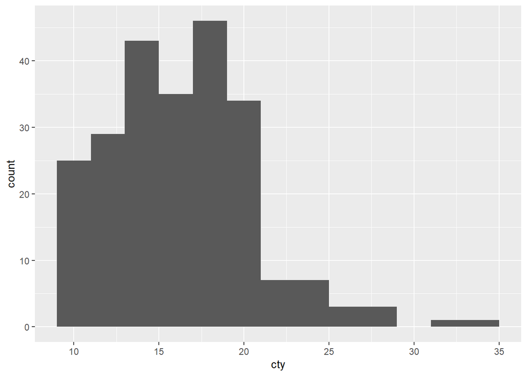

```r
ggplot(m1, aes(x = cty)) +
# ggplot:
# +: overlay
geom_histogram(binwidth = 2)
```

```r
# hitotogram, specify binwidth
```

### Adding colors

```r
p1 <- ggplot(m1, aes(x = cty)) +
  geom_histogram(color="black", fill="orange")
class(p1)
```

```
## [1] "gg"     "ggplot"
```

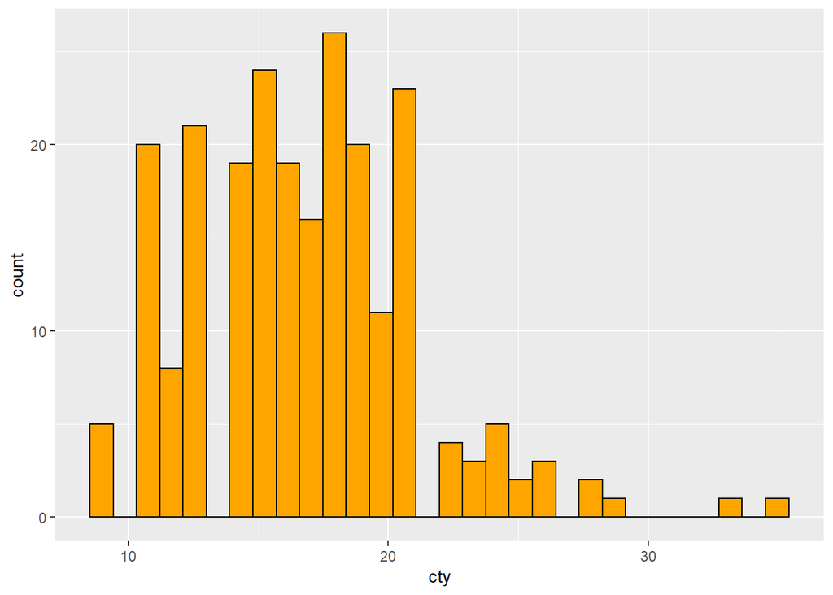

```r
p1
```

### Adding a vertical(mean) line

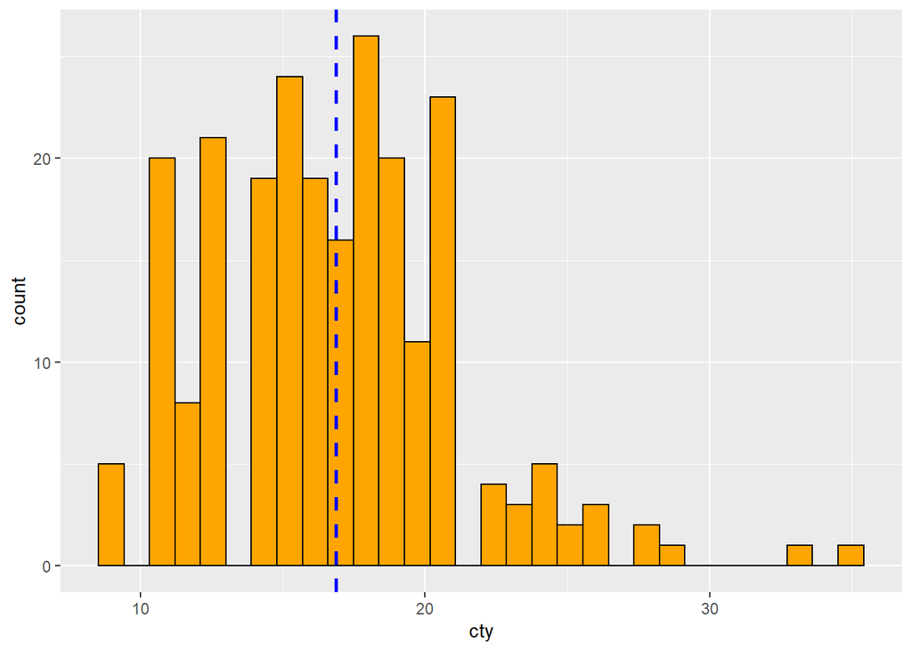

```r
p2 <- p1 + geom_vline(aes(xintercept = mean(cty)),
                      color="blue", linetype="dashed", size=1)
p2
```

## Density

### Probability density function

```r
d <- density(m1$cty)
str(d)
```

```
## List of 7
##  $ x        : num [1:512] 5.62 5.68 5.74 5.81 5.87 ...
##  $ y        : num [1:512] 8.58e-05 1.01e-04 1.20e-04 1.41e-04 1.65e-04 ...
##  $ bw       : num 1.13
##  $ n        : int 234
##  $ call     : language density.default(x = m1$cty)
##  $ data.name: chr "m1$cty"
##  $ has.na   : logi FALSE
##  - attr(*, "class")= chr "density"
```

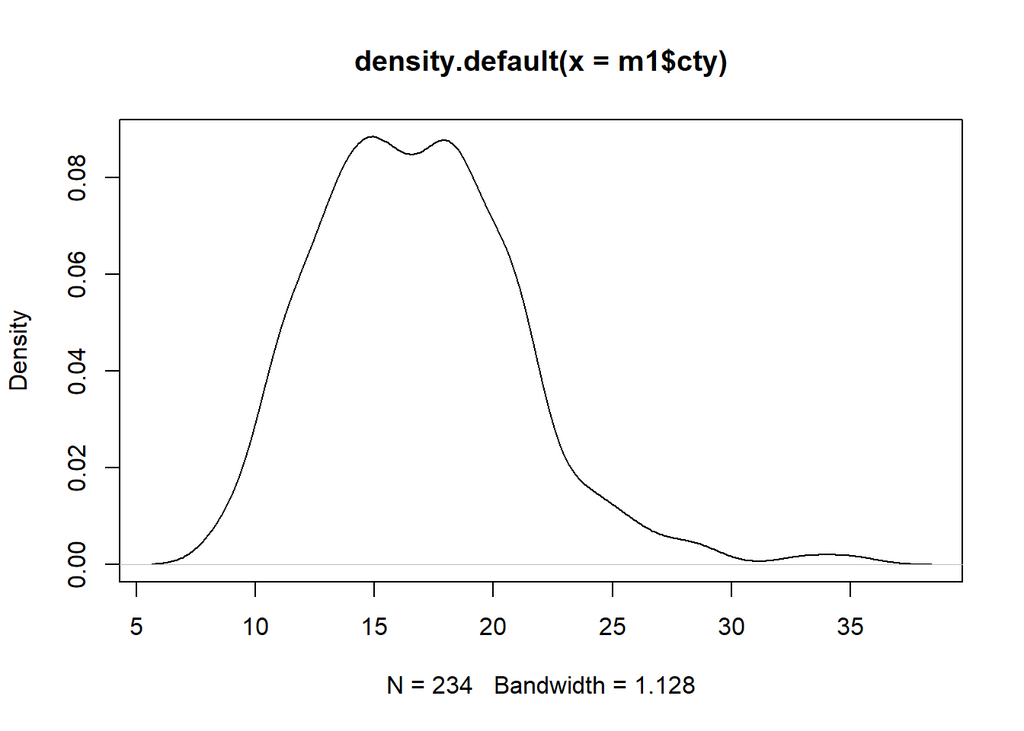

```r
plot(d) # base package
```

### Histogram with density plot

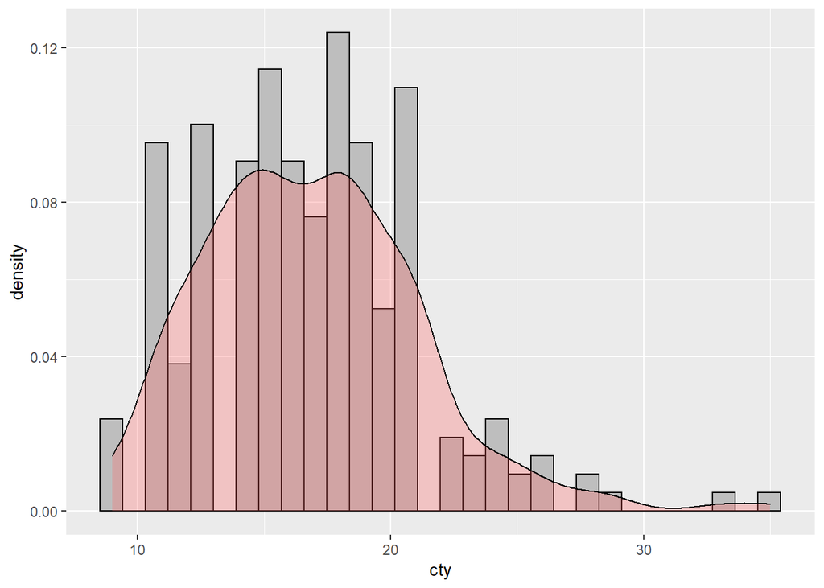

```r
ggplot(m1, aes(x = cty)) +
 geom_histogram(aes(y=..density..), colour="black", fill="gray")+
 geom_density(alpha=.3, fill="#FF6666") # alpha
```

### Overlaid histogram

We want to compare the cty mpg for Large(cyl > 4) and Small(cyl <= 4) cars

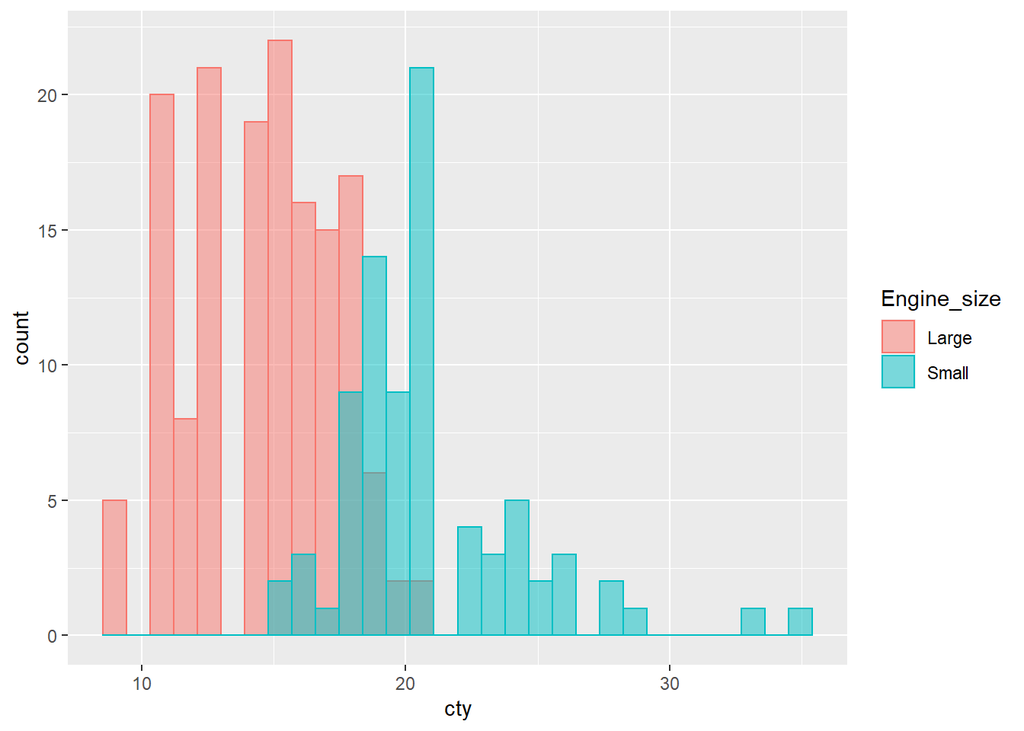

```r
library(dplyr)
m1$Engine_size <- if_else(m1$cyl > 4, "Large", "Small")
# two groups 4 and 5, 6, 8 cyl
p = ggplot(m1, aes(x = cty, color = Engine_size, fill = Engine_size)) +
  geom_histogram(alpha=0.5, position="identity")
p
```

Overlaid histogram and density plot

We want to compare the cty mpg for Large(cyl > 4) and Small(cyl <= 4) cars

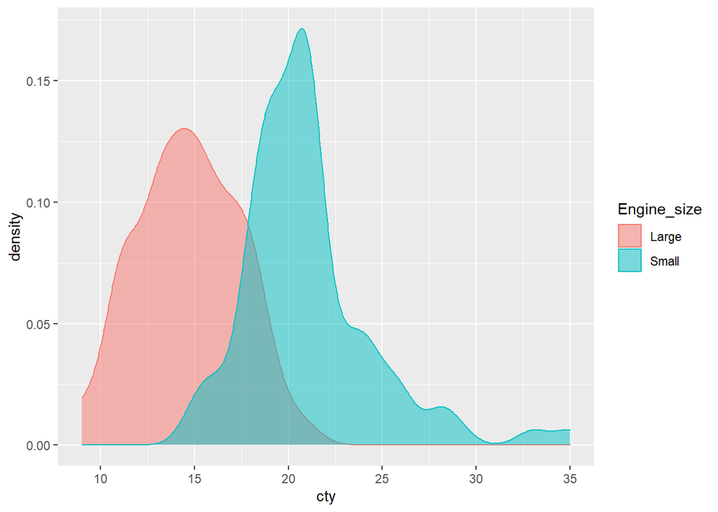

```r
p <- ggplot(m1, aes(x = cty, color = Engine_size, fill = Engine_size)) +
  geom_density(alpha=0.5, position="identity")
p
```

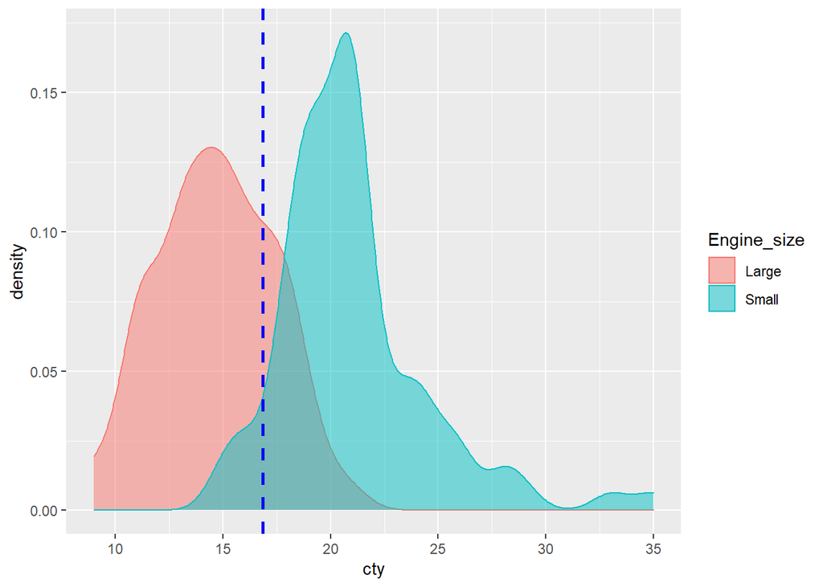

```r
p + geom_vline(aes(xintercept = mean(cty)),
            color="blue", linetype="dashed", size=1)
```

### Change the legend position

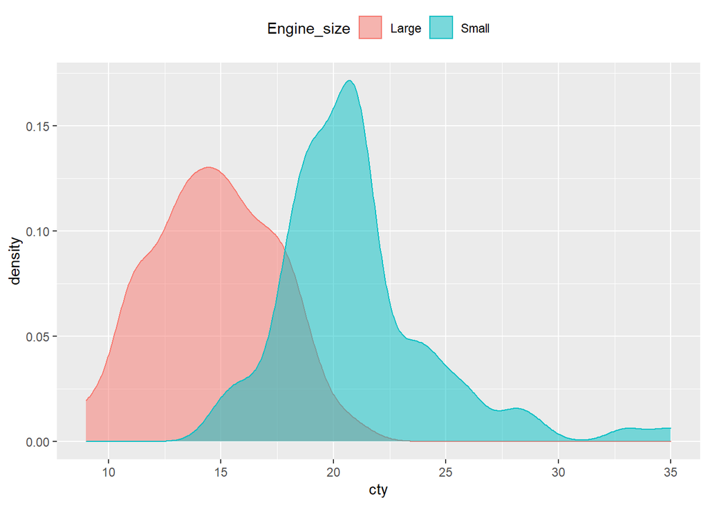

```r
p + theme(legend.position="top") # or bottom, left, right, none
```